# EasyVisa_Full_Code_Rahman

## Problem Statement

### Business Context

Business communities in the United States are facing high demand for human resources, but one of the constant challenges is identifying and attracting the right talent, which is perhaps the most important element in remaining competitive. Companies in the United States look for hard-working, talented, and qualified individuals both locally as well as abroad.

The Immigration and Nationality Act (INA) of the US permits foreign workers to come to the United States to work on either a temporary or permanent basis. The act also protects US workers against adverse impacts on their wages or working conditions by ensuring US employers' compliance with statutory requirements when they hire foreign workers to fill workforce shortages. The immigration programs are administered by the Office of Foreign Labor Certification (OFLC).

OFLC processes job certification applications for employers seeking to bring foreign workers into the United States and grants certifications in those cases where employers can demonstrate that there are not sufficient US workers available to perform the work at wages that meet or exceed the wage paid for the occupation in the area of intended employment.

### Objective

In FY 2016, the OFLC processed 775,979 employer applications for 1,699,957 positions for temporary and permanent labor certifications. This was a nine percent increase in the overall number of processed applications from the previous year. The process of reviewing every case is becoming a tedious task as the number of applicants is increasing every year.

The increasing number of applicants every year calls for a Machine Learning based solution that can help in shortlisting the candidates having higher chances of VISA approval. OFLC has hired the firm EasyVisa for data-driven solutions. You as a data scientist at EasyVisa have to analyze the data provided and, with the help of a classification model:

- Facilitate the process of visa approvals.
- Recommend a suitable profile for the applicants for whom the visa should be certified or denied based on the drivers that significantly influence the case status.

### Data Description

The data contains the different attributes of employee and the employer. The detailed data dictionary is given below.

- case_id: ID of each visa application
- continent: Information of continent the employee
- education_of_employee: Information of education of the employee
- has_job_experience: Does the employee has any job experience? Y= Yes; N = No
- requires_job_training: Does the employee require any job training? Y = Yes; N = No
- no_of_employees: Number of employees in the employer's company
- yr_of_estab: Year in which the employer's company was established
- region_of_employment: Information of foreign worker's intended region of employment in the US.
- prevailing_wage: Average wage paid to similarly employed workers in a specific occupation in the area of intended employment. The purpose of the prevailing wage is to ensure that the foreign worker is not underpaid compared to other workers offering the same or similar service in the same area of employment.
- unit_of_wage: Unit of prevailing wage. Values include Hourly, Weekly, Monthly, and Yearly.
- full_time_position: Is the position of work full-time? Y = Full Time Position; N = Part Time Position
- case_status: Flag indicating if the Visa was certified or denied

## Installing and Importing the necessary libraries

```python
# Installing the libraries with the specified version.
#!pip install numpy==1.25.2 pandas==1.5.3 scikit-learn==1.5.2 matplotlib==3.7.1 seaborn==0.13.1 xgboost==2.0.3 -q --user

# to load and manipulate data
import pandas as pd
import numpy as np

# to visualize data
import matplotlib.pyplot as plt
import seaborn as sns

# to split data into training and test sets
from sklearn.model_selection import train_test_split

# to build decision tree model
from sklearn.tree import DecisionTreeClassifier
from sklearn import tree

# to tune different models
from sklearn.model_selection import GridSearchCV

from sklearn.preprocessing import LabelEncoder

from sklearn.ensemble import BaggingClassifier, RandomForestClassifier

from sklearn.ensemble import AdaBoostClassifier, GradientBoostingClassifier

from xgboost import XGBClassifier

# To undersample and oversample the data
from imblearn.over_sampling import SMOTE
from imblearn.under_sampling import RandomUnderSampler

from sklearn.model_selection import RandomizedSearchCV

import sklearn.metrics as metrics

# to compute classification metrics
from sklearn.metrics import (
    confusion_matrix,
    accuracy_score,
    recall_score,
    precision_score,
    f1_score,
)
```

**Note**: *After running the above cell, kindly restart the notebook kernel and run all cells sequentially from the below.*

```python
from google.colab import drive
drive.mount('/content/drive')
```

## Import Dataset

```python
visa_data = pd.read_csv("/content/drive/MyDrive/Personal/Great Learning/Advanced Machine Learning Course/Assignment/EasyVisa.csv")

data = visa_data.copy()
```

## Overview of the Dataset

#### View the first and last 5 rows of the dataset

```python
data.head(5)
```

|  | case_id | continent | education_of_employee | has_job_experience | requires_job_training | no_of_employees | yr_of_estab | region_of_employment | prevailing_wage | unit_of_wage | full_time_position | case_status |
| --- | --- | --- | --- | --- | --- | --- | --- | --- | --- | --- | --- | --- |
| 0 | EZYV01 | Asia | High School | N | N | 14513 | 2007 | West | 592.2029 | Hour | Y | Denied |
| 1 | EZYV02 | Asia | Master's | Y | N | 2412 | 2002 | Northeast | 83425.6500 | Year | Y | Certified |
| 2 | EZYV03 | Asia | Bachelor's | N | Y | 44444 | 2008 | West | 122996.8600 | Year | Y | Denied |
| 3 | EZYV04 | Asia | Bachelor's | N | N | 98 | 1897 | West | 83434.0300 | Year | Y | Denied |
| 4 | EZYV05 | Africa | Master's | Y | N | 1082 | 2005 | South | 149907.3900 | Year | Y | Certified |

```python
data.tail(5)
```

|  | case_id | continent | education_of_employee | has_job_experience | requires_job_training | no_of_employees | yr_of_estab | region_of_employment | prevailing_wage | unit_of_wage | full_time_position | case_status |
| --- | --- | --- | --- | --- | --- | --- | --- | --- | --- | --- | --- | --- |
| 25475 | EZYV25476 | Asia | Bachelor's | Y | Y | 2601 | 2008 | South | 77092.57 | Year | Y | Certified |
| 25476 | EZYV25477 | Asia | High School | Y | N | 3274 | 2006 | Northeast | 279174.79 | Year | Y | Certified |
| 25477 | EZYV25478 | Asia | Master's | Y | N | 1121 | 1910 | South | 146298.85 | Year | N | Certified |
| 25478 | EZYV25479 | Asia | Master's | Y | Y | 1918 | 1887 | West | 86154.77 | Year | Y | Certified |
| 25479 | EZYV25480 | Asia | Bachelor's | Y | N | 3195 | 1960 | Midwest | 70876.91 | Year | Y | Certified |

#### Understand the shape of the dataset

```python
data.shape
```

```
(25480, 12)
```

The data has 25480 rows and 12 columns

#### Check the data types of the columns for the dataset

```python
data.info()
```

```
<class 'pandas.core.frame.DataFrame'>
RangeIndex: 25480 entries, 0 to 25479
Data columns (total 12 columns):
 #   Column                 Non-Null Count  Dtype
---  ------                 --------------  -----
 0   case_id                25480 non-null  object
 1   continent              25480 non-null  object
 2   education_of_employee  25480 non-null  object
 3   has_job_experience     25480 non-null  object
 4   requires_job_training  25480 non-null  object
 5   no_of_employees        25480 non-null  int64
 6   yr_of_estab            25480 non-null  int64
 7   region_of_employment   25480 non-null  object
 8   prevailing_wage        25480 non-null  float64
 9   unit_of_wage           25480 non-null  object
 10  full_time_position     25480 non-null  object
 11  case_status            25480 non-null  object
dtypes: float64(1), int64(2), object(9)
memory usage: 2.3+ MB
```

There are two int columns and one float column with all the rest of the categorial data as object.

Out of these object types columns continent, education_of_employee, has_job_experience,requires_job_training,region_of_employment,unit_of_wage ,full_time_position and case_status can be of type category. These will be converted later.

## Exploratory Data Analysis (EDA)

#### Let's check the statistical summary of the data

```python
data.describe(include="all").T
```

|  | count | unique | top | freq | mean | std | min | 25% | 50% | 75% | max |
| --- | --- | --- | --- | --- | --- | --- | --- | --- | --- | --- | --- |
| case_id | 25480 | 25480 | EZYV25480 | 1 | NaN | NaN | NaN | NaN | NaN | NaN | NaN |
| continent | 25480 | 6 | Asia | 16861 | NaN | NaN | NaN | NaN | NaN | NaN | NaN |
| education_of_employee | 25480 | 4 | Bachelor's | 10234 | NaN | NaN | NaN | NaN | NaN | NaN | NaN |
| has_job_experience | 25480 | 2 | Y | 14802 | NaN | NaN | NaN | NaN | NaN | NaN | NaN |
| requires_job_training | 25480 | 2 | N | 22525 | NaN | NaN | NaN | NaN | NaN | NaN | NaN |
| no_of_employees | 25480.0 | NaN | NaN | NaN | 5667.04321 | 22877.928848 | -26.0 | 1022.0 | 2109.0 | 3504.0 | 602069.0 |
| yr_of_estab | 25480.0 | NaN | NaN | NaN | 1979.409929 | 42.366929 | 1800.0 | 1976.0 | 1997.0 | 2005.0 | 2016.0 |
| region_of_employment | 25480 | 5 | Northeast | 7195 | NaN | NaN | NaN | NaN | NaN | NaN | NaN |
| prevailing_wage | 25480.0 | NaN | NaN | NaN | 74455.814592 | 52815.942327 | 2.1367 | 34015.48 | 70308.21 | 107735.5125 | 319210.27 |
| unit_of_wage | 25480 | 4 | Year | 22962 | NaN | NaN | NaN | NaN | NaN | NaN | NaN |
| full_time_position | 25480 | 2 | Y | 22773 | NaN | NaN | NaN | NaN | NaN | NaN | NaN |
| case_status | 25480 | 2 | Certified | 17018 | NaN | NaN | NaN | NaN | NaN | NaN | NaN |

#### Fixing the negative values in number of employees columns

```python
negative_count = (data['no_of_employees'] < 0).sum()
print(f"Number of negative entries: {negative_count}")
```

```
Number of negative entries: 33
```

There are approximately 33 rows where employees number is negative

```python
mean_value = data.loc[data['no_of_employees'] >= 0, 'no_of_employees'].mean()
data['no_of_employees'] = data['no_of_employees'].apply(lambda x: x if x >= 0 else mean_value)
```

```python
negative_count = (data['no_of_employees'] < 0).sum()
print(f"Number of negative entries: {negative_count}")
```

```
Number of negative entries: 0
```

After applying the fix there are no negative entries

#### Let's check the count of each unique category in each of the categorical variables

Before checking count the following columns are identified as being category

- continent
- education_of_employee
- has_job_experience
- requires_job_training
- region_of_employment
- unit_of_wage
- full_time_position
- case_status

First converting these from object to type category

```python
data['continent'] = data['continent'].astype('category')
data['education_of_employee'] = data['education_of_employee'].astype('category')
data['has_job_experience'] = data['has_job_experience'].astype('category')
data['requires_job_training'] = data['requires_job_training'].astype('category')
data['region_of_employment'] = data['region_of_employment'].astype('category')
data['unit_of_wage'] = data['unit_of_wage'].astype('category')
data['full_time_position'] = data['full_time_position'].astype('category')
data['case_status'] = data['case_status'].astype('category')
```

```python
data.info()
```

```
<class 'pandas.core.frame.DataFrame'>
RangeIndex: 25480 entries, 0 to 25479
Data columns (total 12 columns):
 #   Column                 Non-Null Count  Dtype
---  ------                 --------------  -----
 0   case_id                25480 non-null  object
 1   continent              25480 non-null  category
 2   education_of_employee  25480 non-null  category
 3   has_job_experience     25480 non-null  category
 4   requires_job_training  25480 non-null  category
 5   no_of_employees        25480 non-null  float64
 6   yr_of_estab            25480 non-null  int64
 7   region_of_employment   25480 non-null  category
 8   prevailing_wage        25480 non-null  float64
 9   unit_of_wage           25480 non-null  category
 10  full_time_position     25480 non-null  category
 11  case_status            25480 non-null  category
dtypes: category(8), float64(2), int64(1), object(1)
memory usage: 996.7+ KB
```

Above confirms the conversion to category. Now getting the counts of each of the category variables

```python
categorical_cols = data.select_dtypes(include=['category']).columns

for col in categorical_cols:
    print(f"\nValue counts for column: {col}")
    print(data[col].value_counts())
```

```
Value counts for column: continent
continent
Asia             16861
Europe            3732
North America     3292
South America      852
Africa             551
Oceania            192
Name: count, dtype: int64

Value counts for column: education_of_employee
education_of_employee
Bachelor's     10234
Master's        9634
High School     3420
Doctorate       2192
Name: count, dtype: int64

Value counts for column: has_job_experience
has_job_experience
Y    14802
N    10678
Name: count, dtype: int64

Value counts for column: requires_job_training
requires_job_training
N    22525
Y     2955
Name: count, dtype: int64

Value counts for column: region_of_employment
region_of_employment
Northeast    7195
South        7017
West         6586
Midwest      4307
Island        375
Name: count, dtype: int64

Value counts for column: unit_of_wage
unit_of_wage
Year     22962
Hour      2157
Week       272
Month       89
Name: count, dtype: int64

Value counts for column: full_time_position
full_time_position
Y    22773
N     2707
Name: count, dtype: int64

Value counts for column: case_status
case_status
Certified    17018
Denied        8462
Name: count, dtype: int64
```

### Univariate Analysis

```python
def histogram_boxplot(data, feature, figsize=(15, 10), kde=False, bins=None):
    """
    Boxplot and histogram combined

    data: dataframe
    feature: dataframe column
    figsize: size of figure (default (15,10))
    kde: whether to show the density curve (default False)
    bins: number of bins for histogram (default None)
    """
    f2, (ax_box2, ax_hist2) = plt.subplots(
        nrows=2,  # Number of rows of the subplot grid= 2
        sharex=True,  # x-axis will be shared among all subplots
        gridspec_kw={"height_ratios": (0.25, 0.75)},
        figsize=figsize,
    )  # creating the 2 subplots
    sns.boxplot(
        data=data, x=feature, ax=ax_box2, showmeans=True, color="violet"
    )  # boxplot will be created and a triangle will indicate the mean value of the column
    sns.histplot(
        data=data, x=feature, kde=kde, ax=ax_hist2, bins=bins
    ) if bins else sns.histplot(
        data=data, x=feature, kde=kde, ax=ax_hist2
    )  # For histogram
    ax_hist2.axvline(
        data[feature].mean(), color="green", linestyle="--"
    )  # Add mean to the histogram
    ax_hist2.axvline(
        data[feature].median(), color="black", linestyle="-"
    )  # Add median to the histogram
```

```python
# function to create labeled barplots


def labeled_barplot(data, feature, perc=False, n=None):
    """
    Barplot with percentage at the top

    data: dataframe
    feature: dataframe column
    perc: whether to display percentages instead of count (default is False)
    n: displays the top n category levels (default is None, i.e., display all levels)
    """

    total = len(data[feature])  # length of the column
    count = data[feature].nunique()
    if n is None:
        plt.figure(figsize=(count + 1, 5))
    else:
        plt.figure(figsize=(n + 1, 5))

    plt.xticks(rotation=90, fontsize=15)
    ax = sns.countplot(
        data=data,
        x=feature,
        palette="Paired",
        order=data[feature].value_counts().index[:n].sort_values(),
    )

    for p in ax.patches:
        if perc == True:
            label = "{:.1f}%".format(
                100 * p.get_height() / total
            )  # percentage of each class of the category
        else:
            label = p.get_height()  # count of each level of the category

        x = p.get_x() + p.get_width() / 2  # width of the plot
        y = p.get_height()  # height of the plot

        ax.annotate(
            label,
            (x, y),
            ha="center",
            va="center",
            size=12,
            xytext=(0, 5),
            textcoords="offset points",
        )  # annotate the percentage

    plt.show()  # show the plot
```

#### Observations on education of employee

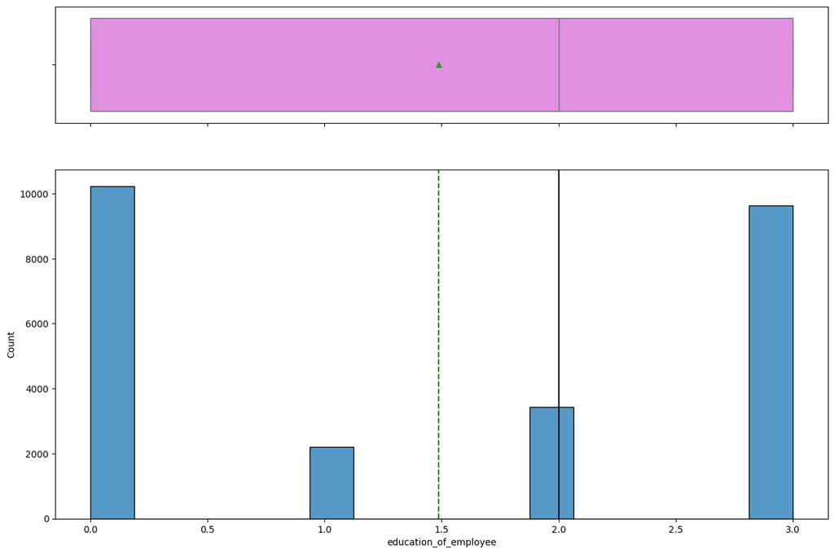

```python
#data['education_of_employee'] = data['education_of_employee'].astype('category')
le = LabelEncoder()

#converting below to numbers so that above function histogram_boxplot can be used to call mean without error
data['education_of_employee'] = le.fit_transform(data['education_of_employee'])

histogram_boxplot(data, "education_of_employee", figsize=(15, 10))
```

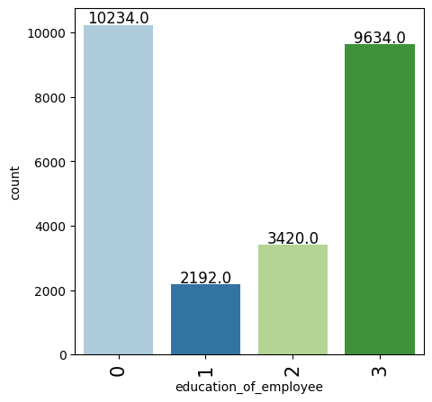

```python
labeled_barplot(data, 'education_of_employee')
```

```python
mapping = dict(zip(le.classes_, le.transform(le.classes_)))
print(mapping)
```

```
{"Bachelor's": np.int64(0), 'Doctorate': np.int64(1), 'High School': np.int64(2), "Master's": np.int64(3)}
```

- 0 is Bacjelors
- 1 is Doctorate
- 2 is High School
- 3 is Master's
- Looking at the data most of them are bachelor's educated followed by Masters then high school and finally doctorate.

#### Observations on region of employment

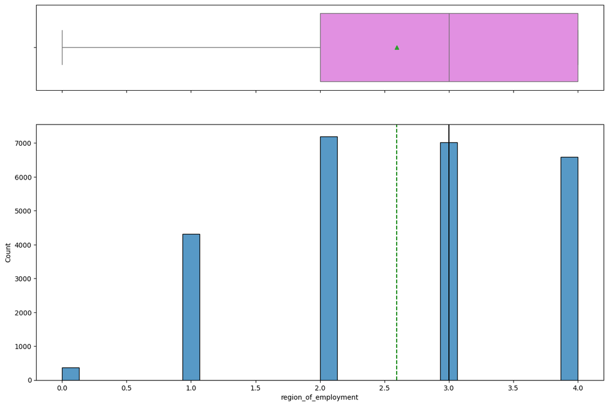

```python
#converting below to numbers so that above function histogram_boxplot can be used to call mean without error
data['region_of_employment'] = le.fit_transform(data['region_of_employment'])

histogram_boxplot(data, "region_of_employment", figsize=(15, 10))
```

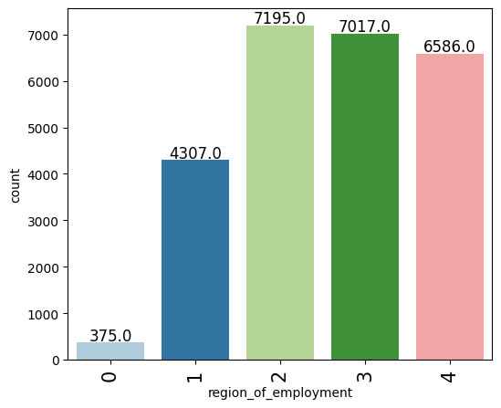

```python
labeled_barplot(data, 'region_of_employment')
```

```python
mapping = dict(zip(le.classes_, le.transform(le.classes_)))
print(mapping)
```

```
{'Island': np.int64(0), 'Midwest': np.int64(1), 'Northeast': np.int64(2), 'South': np.int64(3), 'West': np.int64(4)}
```

- 0 is Island
- 1 is Midwest
- 2 is Northeast
- 3 is South
- 4 is West
- As the data suggests above most of the employees are from the North East region followed by South, West, Midwest and finally Island region.

#### Observations on job experience

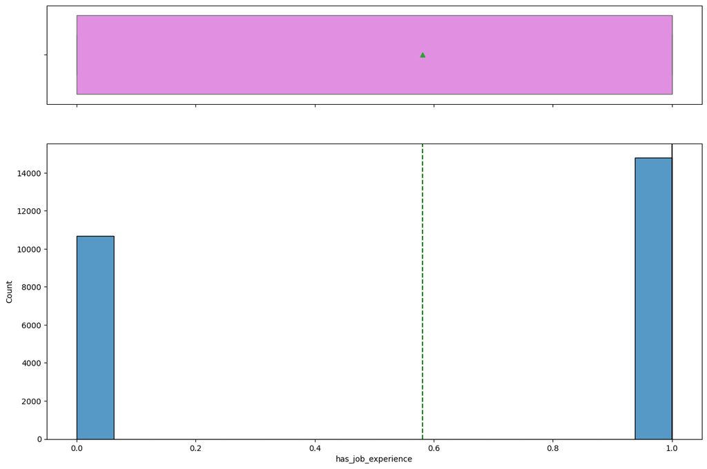

```python
#converting below to numbers so that above function histogram_boxplot can be used to call mean without error
data['has_job_experience'] = le.fit_transform(data['has_job_experience'])

histogram_boxplot(data, "has_job_experience", figsize=(15, 10))
```

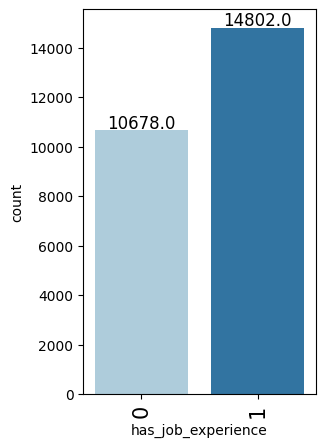

```python
labeled_barplot(data, 'has_job_experience')
```

```python
mapping = dict(zip(le.classes_, le.transform(le.classes_)))
print(mapping)
```

```
{'N': np.int64(0), 'Y': np.int64(1)}
```

- 0 is mapped to N
- 1 is mapped to Y

There are more employees with experience than non-experience. About 10678 do not have job experience while 14,802 employees have job experience

#### Observations on case status

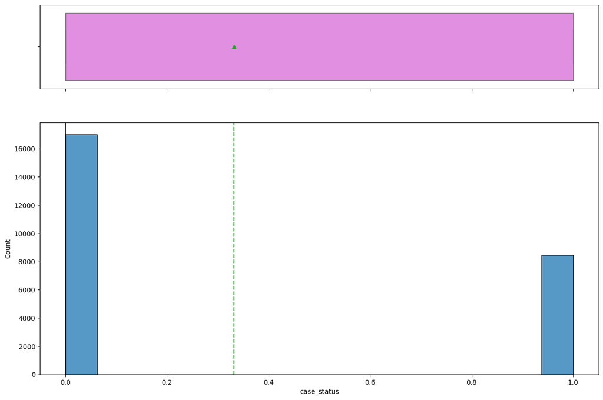

```python
data['case_status'] = le.fit_transform(data['case_status'])

histogram_boxplot(data, "case_status", figsize=(15, 10))
```

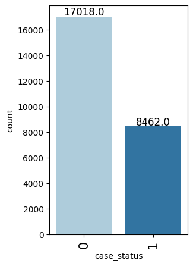

```python
labeled_barplot(data, 'case_status')
```

```python
mapping = dict(zip(le.classes_, le.transform(le.classes_)))
print(mapping)
```

```
{'Certified': np.int64(0), 'Denied': np.int64(1)}
```

- 0 is mapped as Certified
- 1 is mapped as Denied
- Majority cases has been certified (17,018) vs Denied which is at 8,462

### Bivariate Analysis

**Creating functions that will help us with further analysis.**

```python
### function to plot distributions wrt target


def distribution_plot_wrt_target(data, predictor, target):

    fig, axs = plt.subplots(2, 2, figsize=(12, 10))

    target_uniq = data[target].unique()

    axs[0, 0].set_title("Distribution of target for target=" + str(target_uniq[0]))
    sns.histplot(
        data=data[data[target] == target_uniq[0]],
        x=predictor,
        kde=True,
        ax=axs[0, 0],
        color="teal",
        stat="density",
    )

    axs[0, 1].set_title("Distribution of target for target=" + str(target_uniq[1]))
    sns.histplot(
        data=data[data[target] == target_uniq[1]],
        x=predictor,
        kde=True,
        ax=axs[0, 1],
        color="orange",
        stat="density",
    )

    axs[1, 0].set_title("Boxplot w.r.t target")
    sns.boxplot(data=data, x=target, y=predictor, ax=axs[1, 0], palette="gist_rainbow")

    axs[1, 1].set_title("Boxplot (without outliers) w.r.t target")
    sns.boxplot(
        data=data,
        x=target,
        y=predictor,
        ax=axs[1, 1],
        showfliers=False,
        palette="gist_rainbow",
    )

    plt.tight_layout()
    plt.show()
```

```python
def stacked_barplot(data, predictor, target):
    """
    Print the category counts and plot a stacked bar chart

    data: dataframe
    predictor: independent variable
    target: target variable
    """
    count = data[predictor].nunique()
    sorter = data[target].value_counts().index[-1]
    tab1 = pd.crosstab(data[predictor], data[target], margins=True).sort_values(
        by=sorter, ascending=False
    )
    print(tab1)
    print("-" * 120)
    tab = pd.crosstab(data[predictor], data[target], normalize="index").sort_values(
        by=sorter, ascending=False
    )
    tab.plot(kind="bar", stacked=True, figsize=(count + 5, 5))
    plt.legend(
        loc="lower left", frameon=False,
    )
    plt.legend(loc="upper left", bbox_to_anchor=(1, 1))
    plt.show()
```

#### Those with higher education may want to travel abroad for a well-paid job. Let's find out if education has any impact on visa certification

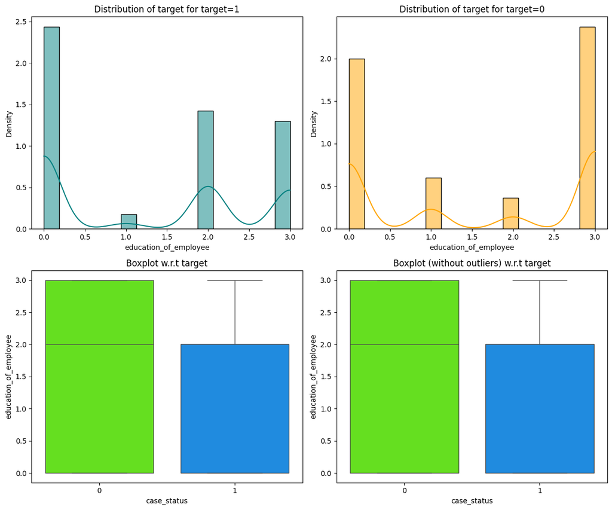

```python
distribution_plot_wrt_target(data, "education_of_employee", "case_status")
```

```
case_status                0     1    All
education_of_employee
All                    17018  8462  25480
0                       6367  3867  10234
2                       1164  2256   3420
3                       7575  2059   9634
1                       1912   280   2192
------------------------------------------------------------------------------------------------------------------------
```

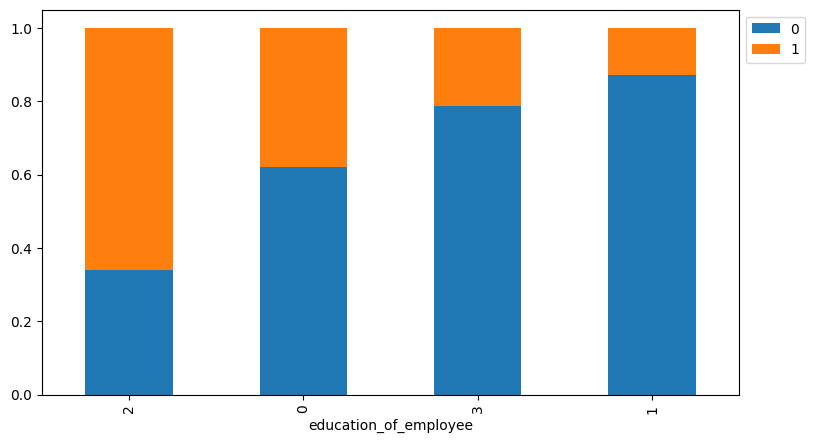

```python
stacked_barplot(data, "education_of_employee", "case_status")
```

Recollect mapping for eduction_of_employee is

- 0 is Bacjelors
- 1 is Doctorate
- 2 is High School
- 3 is Master's

and case_status mapping is

- 0 is mapped as Certified
- 1 is mapped as Denied
- From the above graphs especially from the above bar plot it there is more certified case status than devnied if education level is higher.
- For example Doctorate(1) tends to have the higher certitief case sattus (0) than denied (1) and this trend decreases with lower qualification with masters, bachelors and high school

#### Lets' similarly check for the continents and find out how the visa status vary across different continents.

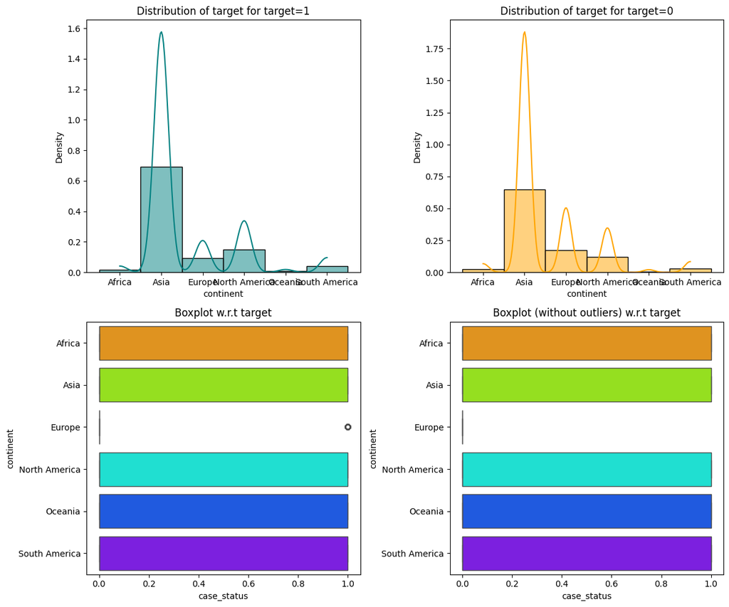

```python
distribution_plot_wrt_target(data, "continent", "case_status")
```

```
case_status        0     1    All
continent
All            17018  8462  25480
Asia           11012  5849  16861
North America   2037  1255   3292
Europe          2957   775   3732
South America    493   359    852
Africa           397   154    551
Oceania          122    70    192
------------------------------------------------------------------------------------------------------------------------
```

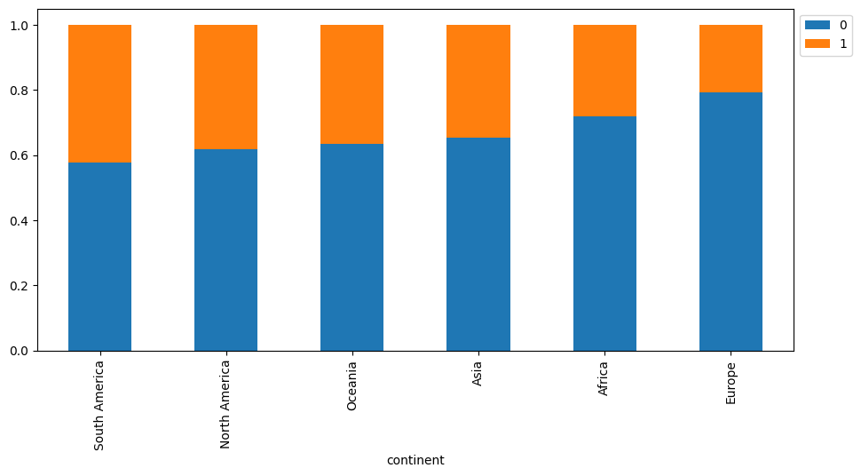

```python
stacked_barplot(data, "continent", "case_status")
```

Recollect case_status mapping is

- 0 is mapped as Certified
- 1 is mapped as Denied
- From the above graphs especially from the above bar plot there is more certified case status than devnied if for Eurpose followed by Africa, Asia, Oceania, North America and South America.

#### Experienced professionals might look abroad for opportunities to improve their lifestyles and career development. Let's see if having work experience has any influence over visa certification

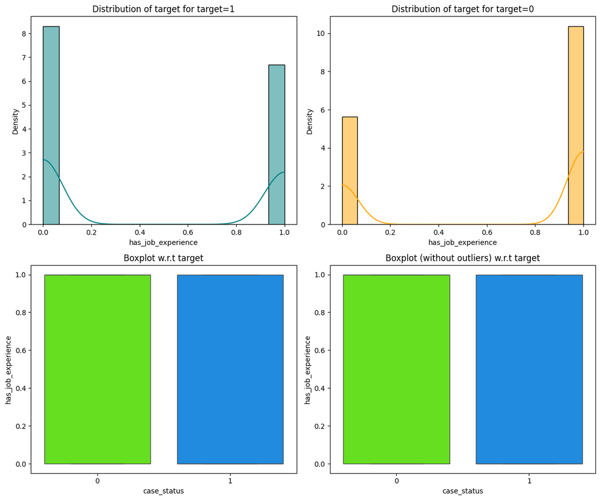

```python
distribution_plot_wrt_target(data, "has_job_experience", "case_status")
```

```
case_status             0     1    All
has_job_experience
All                 17018  8462  25480
0                    5994  4684  10678
1                   11024  3778  14802
------------------------------------------------------------------------------------------------------------------------
```

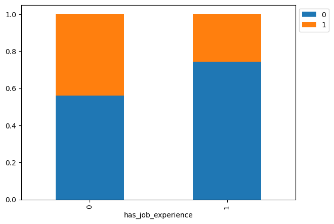

```python
stacked_barplot(data, "has_job_experience", "case_status")
```

Recollect mapping for has_job_experience is

- 0 is mapped to N
- 1 is mapped to Y

and case_status mapping is

- 0 is mapped as Certified
- 1 is mapped as Denied
- From the above graphs especially from the above bar plot it there is slightly more certified case status than devnied if job experience is there with close to 75% in case of job expeience versus 55% with no job experience.

#### Checking if the prevailing wage is similar across all the regions of the US

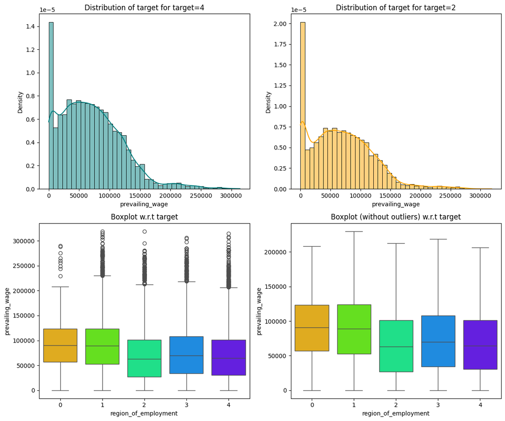

```python
distribution_plot_wrt_target(data, "prevailing_wage", "region_of_employment")
```

#### The US government has established a prevailing wage to protect local talent and foreign workers. Let's analyze the data and see if the visa status changes with the prevailing wage

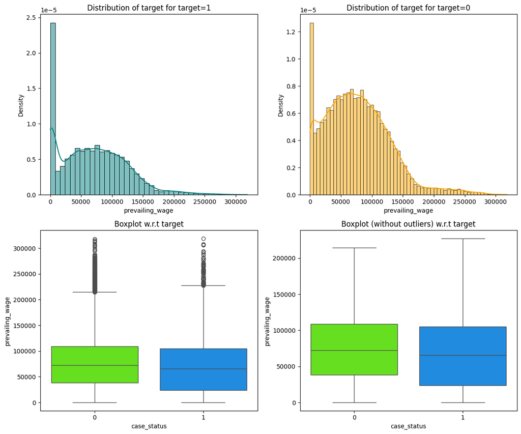

```python
distribution_plot_wrt_target(data, "prevailing_wage", "case_status")
```

Recollect case_status mapping is

- 0 is mapped as Certified
- 1 is mapped as Denied
- Both the graph for prevailing wages for Certified and Denied is right skewed but looking at the box plots there is no substantial difference with cases certified or denied with prevailing wage.

#### The prevailing wage has different units (Hourly, Weekly, etc). Let's find out if it has any impact on visa applications getting certified.

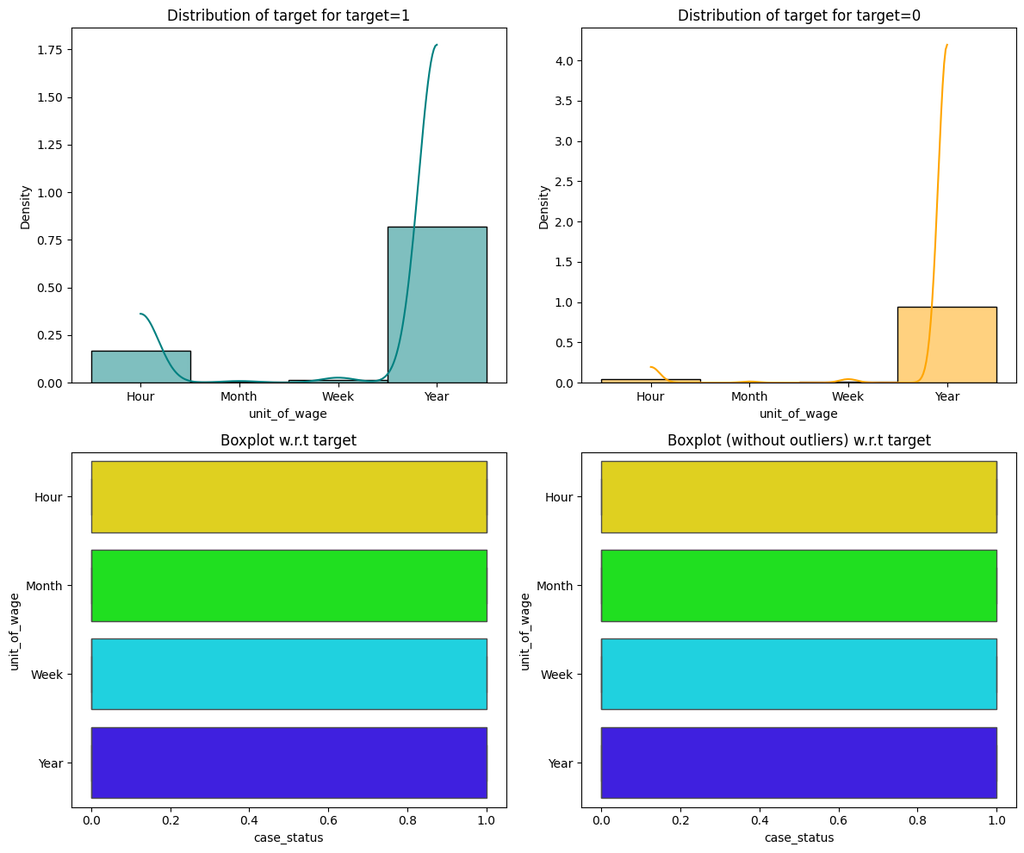

```python
distribution_plot_wrt_target(data, "unit_of_wage", "case_status")
```

```
case_status       0     1    All
unit_of_wage
All           17018  8462  25480
Year          16047  6915  22962
Hour            747  1410   2157
Week            169   103    272
Month            55    34     89
------------------------------------------------------------------------------------------------------------------------
```

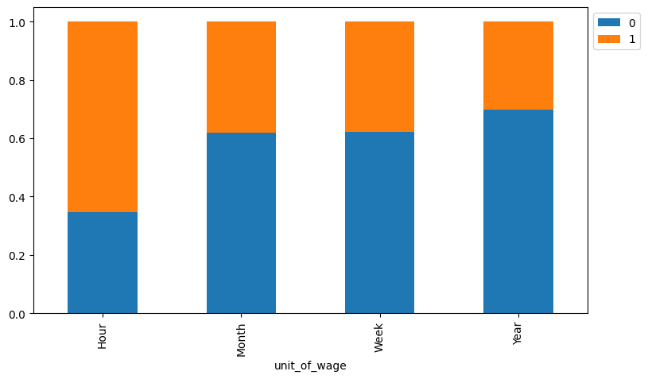

```python
stacked_barplot(data, "unit_of_wage", "case_status")
```

Recollect case_status mapping is

- 0 is mapped as Certified
- 1 is mapped as Denied

There is a more general trend of Certified test cases with more than 60% for month year and week versus hourly employees whose Certified is around 35%.

## Data Pre-processing

### Outlier Check

```python
# checking missing values in the data
data.isna().sum()
```

|  | 0 |
| --- | --- |
| case_id | 0 |
| continent | 0 |
| education_of_employee | 0 |
| has_job_experience | 0 |
| requires_job_training | 0 |
| no_of_employees | 0 |
| yr_of_estab | 0 |
| region_of_employment | 0 |
| prevailing_wage | 0 |
| unit_of_wage | 0 |
| full_time_position | 0 |
| case_status | 0 |

**dtype:** int64

- Data is good with no Nan values

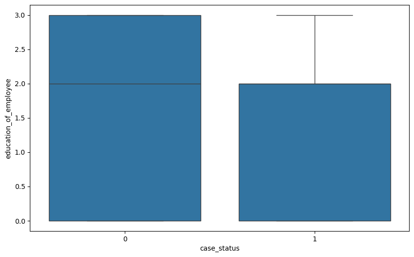

```python
# Case status vs Education of employee
plt.figure(figsize=(10, 6))
sns.boxplot(data=data, x='case_status', y='education_of_employee');
```

Recollecting what education_of_employee is mapped

- 0 is Bacjelors
- 1 is Doctorate
- 2 is High School
- 3 is Master's

there is not much outliers.

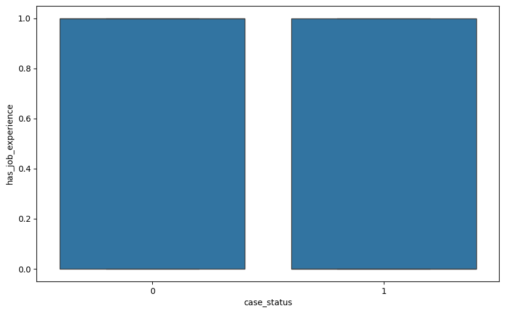

```python
# Case status vs has_job_experience
plt.figure(figsize=(10, 6))
sns.boxplot(data=data, x='case_status', y='has_job_experience');
```

There are not much ouliers for case status vs job experience

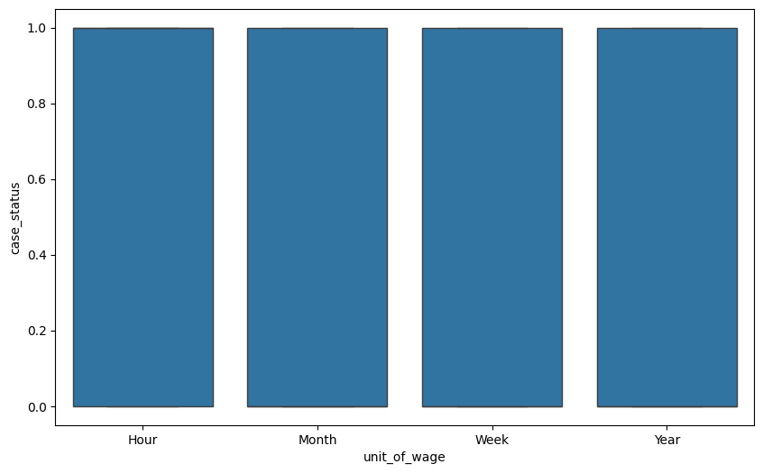

```python
# "unit_of_wage", "case_status"
plt.figure(figsize=(10, 6))
sns.boxplot(data=data, x='unit_of_wage', y='case_status');
```

There are not much ouliers for case status vs unit of wage

```python
# checking the distribution of the target variable
data["case_status"].value_counts(1)
```

| case_status | proportion |
| --- | --- |
| 0 | 0.667896 |
| 1 | 0.332104 |

**dtype:** float64

### Data Preparation for modeling

```python
# defining the explanatory (independent) and response (dependent) variables
X = data.drop(["case_status", "case_id"], axis=1)
y = data["case_status"]
```

```python
# creating dummy variables
X = pd.get_dummies(X, columns=X.select_dtypes(include=["object", "category"]).columns.tolist(), drop_first=True)

# specifying the datatype of the independent variables data frame
X = X.astype(float)

X.head()
```

|  | education_of_employee | has_job_experience | no_of_employees | yr_of_estab | region_of_employment | prevailing_wage | continent_Asia | continent_Europe | continent_North America | continent_Oceania | continent_South America | requires_job_training_Y | unit_of_wage_Month | unit_of_wage_Week | unit_of_wage_Year | full_time_position_Y |
| --- | --- | --- | --- | --- | --- | --- | --- | --- | --- | --- | --- | --- | --- | --- | --- | --- |
| 0 | 2.0 | 0.0 | 14513.0 | 2007.0 | 4.0 | 592.2029 | 1.0 | 0.0 | 0.0 | 0.0 | 0.0 | 0.0 | 0.0 | 0.0 | 0.0 | 1.0 |
| 1 | 3.0 | 1.0 | 2412.0 | 2002.0 | 2.0 | 83425.6500 | 1.0 | 0.0 | 0.0 | 0.0 | 0.0 | 0.0 | 0.0 | 0.0 | 1.0 | 1.0 |
| 2 | 0.0 | 0.0 | 44444.0 | 2008.0 | 4.0 | 122996.8600 | 1.0 | 0.0 | 0.0 | 0.0 | 0.0 | 1.0 | 0.0 | 0.0 | 1.0 | 1.0 |
| 3 | 0.0 | 0.0 | 98.0 | 1897.0 | 4.0 | 83434.0300 | 1.0 | 0.0 | 0.0 | 0.0 | 0.0 | 0.0 | 0.0 | 0.0 | 1.0 | 1.0 |
| 4 | 3.0 | 1.0 | 1082.0 | 2005.0 | 3.0 | 149907.3900 | 0.0 | 0.0 | 0.0 | 0.0 | 0.0 | 0.0 | 0.0 | 0.0 | 1.0 | 1.0 |

```python
#no need to change y as it is already 0 or 1
y.head()
```

|  | case_status |
| --- | --- |
| 0 | 1 |
| 1 | 0 |
| 2 | 1 |
| 3 | 1 |
| 4 | 0 |

**dtype:** int64

```python
# splitting the data in an 80:20 ratio for train and test sets
X_train, X_test, y_train, y_test = train_test_split(X, y, test_size=0.20, stratify=y, random_state=42)    # stratify ensures that the training and test sets have a similar distribution of the response variable
```

```python
print("Shape of training set:", X_train.shape)
print("Shape of test set:", X_test.shape, '\n')
print("Percentage of classes in training set:")
print(100*y_train.value_counts(normalize=True), '\n')
print("Percentage of classes in test set:")
print(100*y_test.value_counts(normalize=True))
```

```
Shape of training set: (20384, 16)
Shape of test set: (5096, 16)

Percentage of classes in training set:
case_status
0    66.787677
1    33.212323
Name: proportion, dtype: float64

Percentage of classes in test set:
case_status
0    66.797488
1    33.202512
Name: proportion, dtype: float64
```

## Model Building

### Model Evaluation Criterion

```python
# defining a function to compute different metrics to check performance of a classification model built using sklearn


def model_performance_classification_sklearn(model, predictors, target):
    """
    Function to compute different metrics to check classification model performance

    model: classifier
    predictors: independent variables
    target: dependent variable
    """

    # predicting using the independent variables
    pred = model.predict(predictors)

    acc = accuracy_score(target, pred)  # to compute Accuracy
    recall = recall_score(target, pred)  # to compute Recall
    precision = precision_score(target, pred)  # to compute Precision
    f1 = f1_score(target, pred)  # to compute F1-score

    # creating a dataframe of metrics
    df_perf = pd.DataFrame(
        {"Accuracy": acc, "Recall": recall, "Precision": precision, "F1": f1,},
        index=[0],
    )

    return df_perf
```

```python
def confusion_matrix_sklearn(model, predictors, target):
    """
    To plot the confusion_matrix with percentages

    model: classifier
    predictors: independent variables
    target: dependent variable
    """
    y_pred = model.predict(predictors)
    cm = confusion_matrix(target, y_pred)
    labels = np.asarray(
        [
            ["{0:0.0f}".format(item) + "\n{0:.2%}".format(item / cm.flatten().sum())]
            for item in cm.flatten()
        ]
    ).reshape(2, 2)

    plt.figure(figsize=(6, 4))
    sns.heatmap(cm, annot=labels, fmt="")
    plt.ylabel("True label")
    plt.xlabel("Predicted label")
```

### Model building with original data

```python
# creating an instance of the decision tree model
dtree1 = DecisionTreeClassifier(random_state=42)    # random_state sets a seed value and enables reproducibility

# fitting the model to the training data
dtree1.fit(X_train, y_train)
```

```
DecisionTreeClassifier(random_state=42)
```

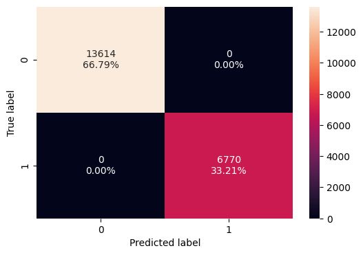

```python
confusion_matrix_sklearn(dtree1, X_train, y_train)
```

```python
dtree1_train_perf = model_performance_classification_sklearn(
    dtree1, X_train, y_train
)
dtree1_train_perf
```

|  | Accuracy | Recall | Precision | F1 |
| --- | --- | --- | --- | --- |
| 0 | 1.0 | 1.0 | 1.0 | 1.0 |

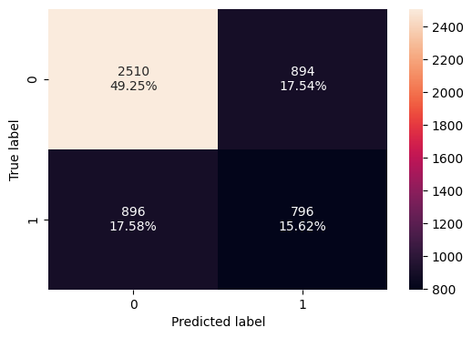

```python
confusion_matrix_sklearn(dtree1, X_test, y_test)
```

```python
dtree1_test_perf = model_performance_classification_sklearn(
    dtree1, X_test, y_test
)
dtree1_test_perf
```

|  | Accuracy | Recall | Precision | F1 |
| --- | --- | --- | --- | --- |
| 0 | 0.648744 | 0.470449 | 0.471006 | 0.470727 |

- There is a difference between the training and test F1 Scores.
- This indicates that the model is overfitting.

#### Visualizing the decision tree

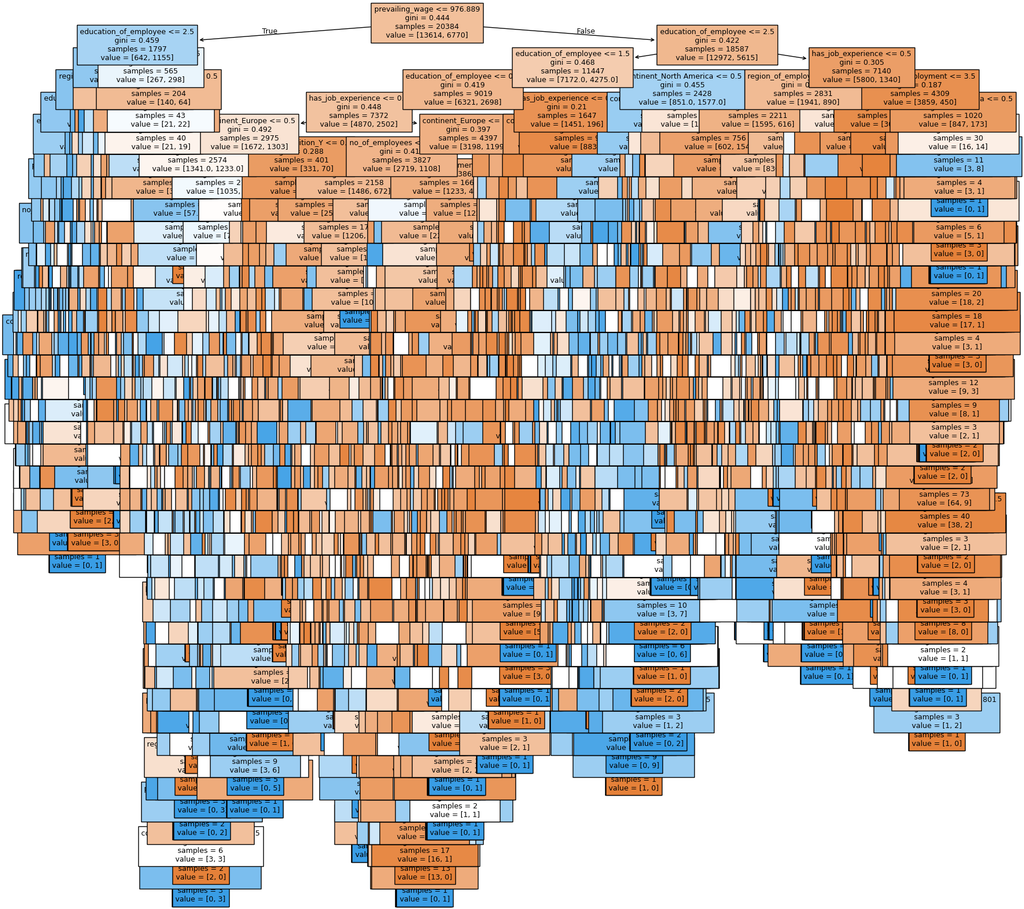

```python
# list of feature names in X_train
feature_names = list(X_train.columns)

# set the figure size for the plot
plt.figure(figsize=(20, 20))

# plotting the decision tree
out = tree.plot_tree(
    dtree1,                         # decision tree classifier model
    feature_names=feature_names,    # list of feature names (columns) in the dataset
    filled=True,                    # fill the nodes with colors based on class
    fontsize=9,                     # font size for the node text
    node_ids=False,                 # do not show the ID of each node
    class_names=None,               # whether or not to display class names
)

# add arrows to the decision tree splits if they are missing
for o in out:
    arrow = o.arrow_patch
    if arrow is not None:
        arrow.set_edgecolor("black")    # set arrow color to black
        arrow.set_linewidth(1)          # set arrow linewidth to 1

# displaying the plot
plt.show()
```

- We can observe from the above the decision tree is too complex.
- Let us use the pre-pruning technique

```python
# define the parameters of the tree to iterate over
max_depth_values = np.arange(2, 11, 2)
max_leaf_nodes_values = np.arange(10, 51, 10)
min_samples_split_values = np.arange(10, 51, 10)

# initialize variables to store the best model and its performance
best_estimator = None
best_score_diff = float('inf')

# iterate over all combinations of the specified parameter values
for max_depth in max_depth_values:
    for max_leaf_nodes in max_leaf_nodes_values:
        for min_samples_split in min_samples_split_values:

            # initialize the tree with the current set of parameters
            estimator = DecisionTreeClassifier(
                max_depth=max_depth,
                max_leaf_nodes=max_leaf_nodes,
                min_samples_split=min_samples_split,
                random_state=42
            )

            # fit the model to the training data
            estimator.fit(X_train, y_train)

            # make predictions on the training and test sets
            y_train_pred = estimator.predict(X_train)
            y_test_pred = estimator.predict(X_test)

            # calculate F1 scores for training and test sets
            train_f1_score = f1_score(y_train, y_train_pred)
            test_f1_score = f1_score(y_test, y_test_pred)

            # calculate the absolute difference between training and test F1 scores
            score_diff = abs(train_f1_score - test_f1_score)

            # update the best estimator and best score if the current one has a smaller score difference
            if score_diff < best_score_diff:
                best_score_diff = score_diff
                best_estimator = estimator
```

```python
# creating an instance of the best model
dtree2 = best_estimator

# fitting the best model to the training data
dtree2.fit(X_train, y_train)
```

```
DecisionTreeClassifier(max_depth=np.int64(8), max_leaf_nodes=np.int64(10),
                       min_samples_split=np.int64(10), random_state=42)
```

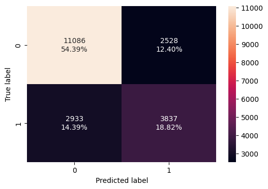

```python
confusion_matrix_sklearn(dtree2, X_train, y_train)
```

```python
dtree2_train_perf = model_performance_classification_sklearn(
    dtree2, X_train, y_train
)
dtree2_train_perf
```

|  | Accuracy | Recall | Precision | F1 |
| --- | --- | --- | --- | --- |
| 0 | 0.732094 | 0.566765 | 0.602828 | 0.584241 |

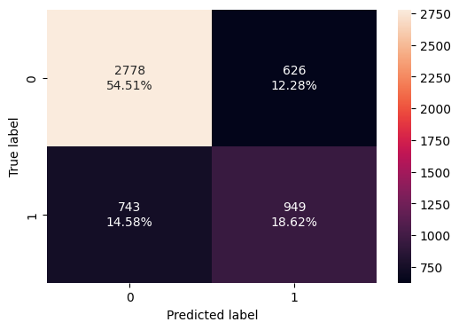

```python
confusion_matrix_sklearn(dtree2, X_test, y_test)
```

```python
dtree2_test_perf = model_performance_classification_sklearn(
    dtree2, X_test, y_test
)
dtree2_test_perf
```

|  | Accuracy | Recall | Precision | F1 |
| --- | --- | --- | --- | --- |
| 0 | 0.731358 | 0.560875 | 0.60254 | 0.580961 |

- **After prepruning the training and test scores are very close to each other, indicating a generalized performance.**

### Now using Bagging Classifier

```python
#base_estimator for bagging classifier is a decision tree by default
bagging_estimator=BaggingClassifier(random_state=1)
bagging_estimator.fit(X_train,y_train)
```

```
BaggingClassifier(random_state=1)
```

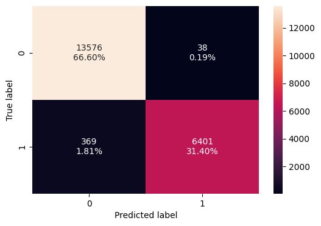

```python
#Using above defined function to get accuracy, recall and precision on train and test set
confusion_matrix_sklearn(bagging_estimator, X_train, y_train)
```

```python
bagging_estimator_train_perf = model_performance_classification_sklearn(
    bagging_estimator, X_train, y_train
)
bagging_estimator_train_perf
```

|  | Accuracy | Recall | Precision | F1 |
| --- | --- | --- | --- | --- |
| 0 | 0.980033 | 0.945495 | 0.994098 | 0.969188 |

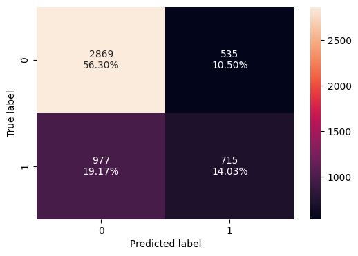

```python
#Using above defined function to get accuracy, recall and precision on train and test set
confusion_matrix_sklearn(bagging_estimator, X_test, y_test)
```

```python
bagging_estimator_test_perf = model_performance_classification_sklearn(
    bagging_estimator, X_test, y_test
)
bagging_estimator_test_perf
```

|  | Accuracy | Recall | Precision | F1 |
| --- | --- | --- | --- | --- |
| 0 | 0.703297 | 0.422577 | 0.572 | 0.486064 |

- There is a difference between the training and test F1 Scores.This indicates that the model is overfitting.
- Not hypertuning this intentionally now as the best three models will be hypertuned later in the section. Hence we will now consider Random Forest

### Now using Random Forest Classifier

```python
#Train the random forest classifier
rf_estimator=RandomForestClassifier(random_state=1)
rf_estimator.fit(X_train,y_train)
```

```
RandomForestClassifier(random_state=1)
```

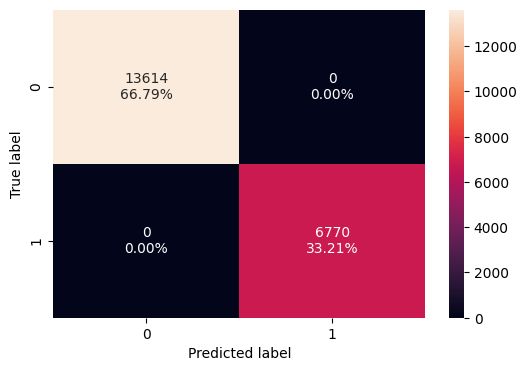

```python
#Using above defined function to get accuracy, recall and precision on train and test set
confusion_matrix_sklearn(rf_estimator, X_train, y_train)
```

```python
rf_estimator_train_perf = model_performance_classification_sklearn(
    rf_estimator, X_train, y_train
)
rf_estimator_train_perf
```

|  | Accuracy | Recall | Precision | F1 |
| --- | --- | --- | --- | --- |
| 0 | 1.0 | 1.0 | 1.0 | 1.0 |

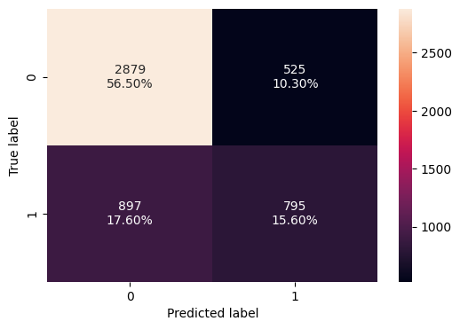

```python
#Using above defined function to get accuracy, recall and precision on train and test set
confusion_matrix_sklearn(rf_estimator, X_test, y_test)
```

```python
rf_estimator_test_perf = model_performance_classification_sklearn(
    rf_estimator, X_test, y_test
)
rf_estimator_test_perf
```

|  | Accuracy | Recall | Precision | F1 |
| --- | --- | --- | --- | --- |
| 0 | 0.720958 | 0.469858 | 0.602273 | 0.527888 |

- There is a difference between the training and test F1 Scores.This indicates that the model is overfitting.
- Not hypertuning this intentionally now as the best three models will be hypertuned later in the section. Hence we will now consider Ada Boost